# ADS 506 Module 6 Exercises

Gabi Rivera

2023-12-03

## Chapter 9: Neural Networks (Page 201): #2 & 3

Forecasting Australian Wine Sales: Figure 6.26 shows time plots of monthly sales of six types of Australian wines (red, rose, sweet white, dry white, sparkling, and fortified) for 1980-1994. Data available in AustralianWines.csv. The units are thousands of liters. You are hired to obtain short-term forecasts (2-3 months ahead) for each of the six series, and this task will be repeated every month.

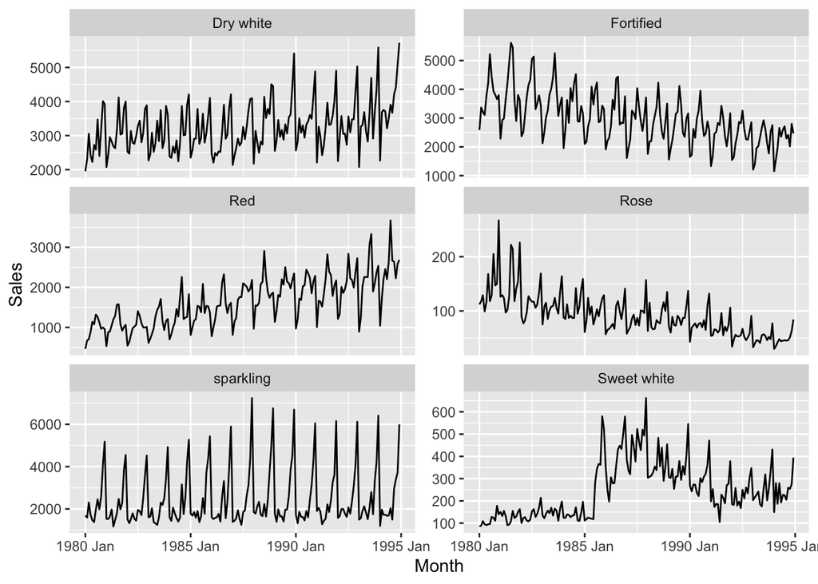

```r
wines <- read_csv("AustralianWines.csv",
         show_col_types = FALSE) |>
         mutate(Month = as.Date(paste(Month, '01'), format = "%b-%y %d") |>
         yearmonth())

wines_ts <- subset(wines, select=c("Month", "Fortified")) |>
            as_tsibble(index = Month)


wines |>
    pivot_longer(-Month, names_to = "Wine", values_to = "Sales") |>
    ggplot(aes(x = Month, y = Sales)) +
    geom_line() +
    facet_wrap(Wine ~ ., scales = "free_y", ncol = 2)
```

## 2. Use neural networks to forecast fortified wine sales, as follows:

● Partition the data using the period until December 1993 as the training period.

```r
# create training set
wines_trn = wines_ts |>
            filter_index(.~ "1993 Dec")

# create validation set
wines_val = wines_ts |>
            anti_join(wines_trn, by = 'Month')
```

● Run a neural network using R’s nnetar with 11 non-seasonal lags (i.e., p = 11). Leave all other arguments at their default.

```r
# train the model
wine_nnetar = wines_trn |>
    model(nnetar = NNETAR(Fortified, p = 11))
wine_nnetar
```

| nnetar |
| --- |

```r
# forecast
wine_pred = forecast(wine_nnetar,h=12)
wine_pred
```

| .model | Month | Fortified | .mean |
| --- | --- | --- | --- |
| nnetar | 1994 Jan |  | 1252.399 |
| nnetar | 1994 Feb |  | 1337.859 |
| nnetar | 1994 Mar |  | 2002.467 |
| nnetar | 1994 Apr |  | 2101.400 |
| nnetar | 1994 May |  | 2267.884 |
| nnetar | 1994 Jun |  | 2483.031 |
| nnetar | 1994 Jul |  | 2688.734 |
| nnetar | 1994 Aug |  | 2530.968 |
| nnetar | 1994 Sep |  | 1940.279 |
| nnetar | 1994 Oct |  | 1616.780 |

[output cut: 2 more lines]

1. Create a time plot for the actual and forecasted series over the training period. Create also a time plot of the forecast errors for the training period. Interpret what you see in the plots.

```
## Plot variable not specified, automatically selected `.vars = .fitted`
```

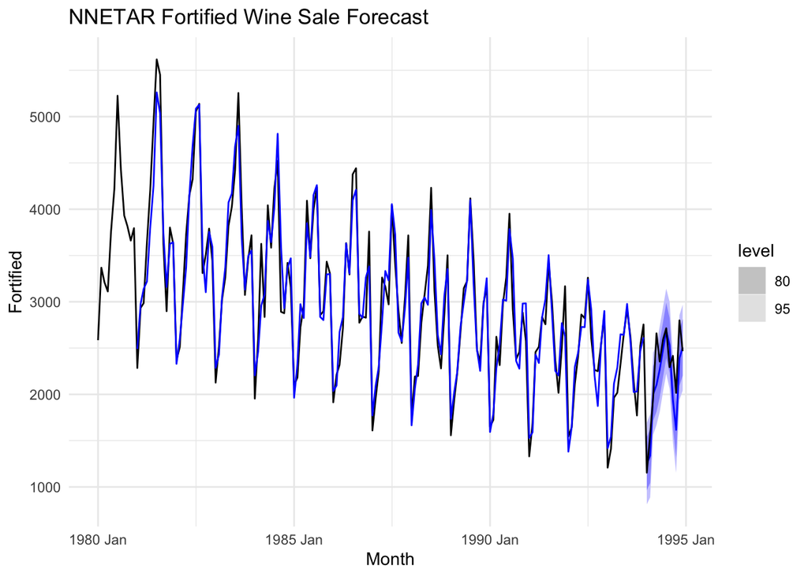

```r
# plot the fitted values with the actuals for the training period
fitted_values <- fitted(wine_nnetar)

wine_pred |>
  autoplot(wines_ts) +
  autolayer(fitted_values, colour = 'blue')+
  theme_minimal() +
  labs(title = "NNETAR Fortified Wine Sale Forecast")
```

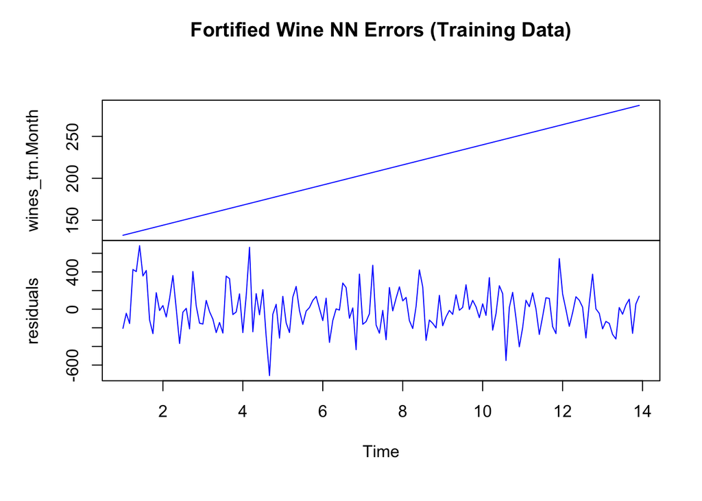

```r
# Create also a time plot of the forecast errors for the training period

observed_values <- as.numeric(wines_trn$Fortified)
predicted_values <- as.numeric(fitted_values$.fitted)
residuals <- observed_values - predicted_values
nresid <- data.frame(wines_trn$Month, residuals)
df_clean <- na.omit(nresid)
resid = ts(df_clean, frequency = 12)


plot(resid,ylab="Residuals",
     main = "Fortified Wine NN Errors (Training Data)",
     col = "blue")
```

2. Use the neural network to forecast sales for each month in the validation period (January 1994 to December 1994).

```r
# validation
head(wines_val)
```

| Month | Fortified |
| --- | --- |
| 1994 Jan | 1154 |
| 1994 Feb | 1568 |
| 1994 Mar | 1965 |
| 1994 Apr | 2659 |
| 1994 May | 2354 |
| 1994 Jun | 2592 |

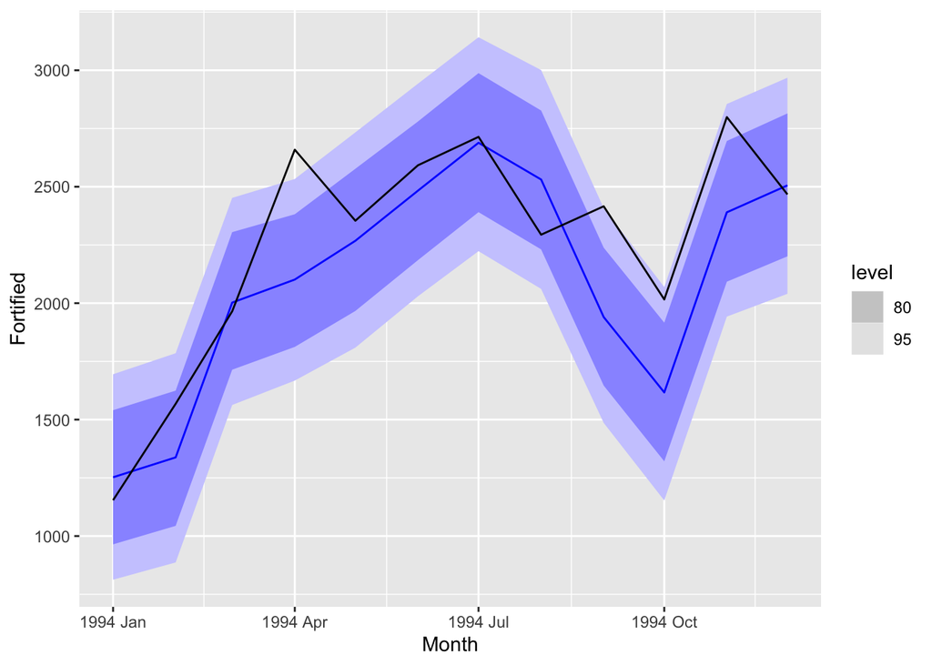

```r
#plot the forecast
fc = wine_pred |>
      autoplot(wines_val)
fc
```

```r
#output the forecast for the months requested
wine_pred
```

| .model | Month | Fortified | .mean |
| --- | --- | --- | --- |
| nnetar | 1994 Jan |  | 1252.399 |
| nnetar | 1994 Feb |  | 1337.859 |
| nnetar | 1994 Mar |  | 2002.467 |
| nnetar | 1994 Apr |  | 2101.400 |
| nnetar | 1994 May |  | 2267.884 |
| nnetar | 1994 Jun |  | 2483.031 |
| nnetar | 1994 Jul |  | 2688.734 |
| nnetar | 1994 Aug |  | 2530.968 |
| nnetar | 1994 Sep |  | 1940.279 |
| nnetar | 1994 Oct |  | 1616.780 |

[output cut: 2 more lines]

```r
#report the forecast accuracy for the months requested
accuracy(wine_pred, wines_val)
```

| .model | .type | ME | RMSE | MAE | MPE | MAPE | MASE | RMSSE | ACF1 |
| --- | --- | --- | --- | --- | --- | --- | --- | --- | --- |
| nnetar | Test | 156.689 | 289.4538 | 225.2917 | 6.350464 | 10.07304 | NaN | NaN | -0.1605309 |

## 3. Compare your neural network to an exponential smoothing model used to forecast fortified wine sales.

1. Use R’s ets function to automatically select and fit an exponential smoothing model to the training period until December 1993. Which model did ets fit?

ETS chose and fit the MAM model in this case.

```r
# fit models
wine_ets = wines_trn |>
    model(ets = ETS(Fortified))
wine_ets
```

| ets |
| --- |

2. Use this exponential smoothing model to forecast sales for each month in 1994.

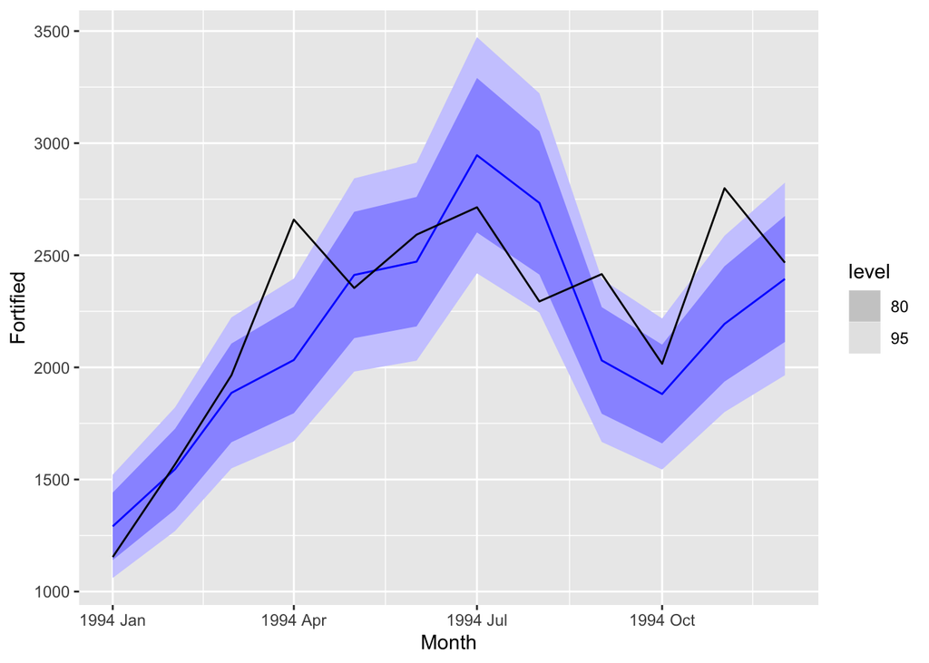

```r
# forecast the next 12 months
wine_ets_pred <- forecast(wine_ets, h = 12)

# plot the forecasts
wine_ets_pred |>
  autoplot(wines_val)
```

```r
# output the forecast for the months requested
wine_ets_pred
```

| .model | Month | Fortified | .mean |
| --- | --- | --- | --- |
| ets | 1994 Jan |  | 1290.973 |
| ets | 1994 Feb |  | 1546.065 |
| ets | 1994 Mar |  | 1886.199 |
| ets | 1994 Apr |  | 2032.918 |
| ets | 1994 May |  | 2412.106 |
| ets | 1994 Jun |  | 2471.522 |
| ets | 1994 Jul |  | 2946.189 |
| ets | 1994 Aug |  | 2733.496 |
| ets | 1994 Sep |  | 2030.893 |
| ets | 1994 Oct |  | 1881.176 |

[output cut: 2 more lines]

3. How does the neural network compare to the exponential smoothing model in terms of predictive performance in the training period? In the validation period?

```r
# NNETAR
accuracy(wine_nnetar)
```

| .model | .type | ME | RMSE | MAE | MPE | MAPE | MASE | RMSSE | ACF1 |
| --- | --- | --- | --- | --- | --- | --- | --- | --- | --- |
| nnetar | Training | -0.03085785 | 224.2451 | 171.6837 | -0.7493967 | 5.960064 | 0.6169982 | 0.6307745 | 0.08403545 |

```r
accuracy(wine_pred, wines_val)
```

| .model | .type | ME | RMSE | MAE | MPE | MAPE | MASE | RMSSE | ACF1 |
| --- | --- | --- | --- | --- | --- | --- | --- | --- | --- |
| nnetar | Test | 156.689 | 289.4538 | 225.2917 | 6.350464 | 10.07304 | NaN | NaN | -0.1605309 |

```r
# ETS
accuracy(wine_ets)
```

| .model | .type | ME | RMSE | MAE | MPE | MAPE | MASE | RMSSE | ACF1 |
| --- | --- | --- | --- | --- | --- | --- | --- | --- | --- |
| ets | Training | 15.49844 | 285.2321 | 222.3198 | -0.04620971 | 7.098462 | 0.7989745 | 0.8023235 | 0.06838359 |

```r
accuracy(wine_ets_pred,wines_val)
```

| .model | .type | ME | RMSE | MAE | MPE | MAPE | MASE | RMSSE | ACF1 |
| --- | --- | --- | --- | --- | --- | --- | --- | --- | --- |
| ets | Test | 98.19161 | 318.9037 | 242.6523 | 3.228787 | 10.23738 | NaN | NaN | -0.04043727 |